# Zróżnicowanie poziomu życia w województwie Śląskim

Kacper Prorok

2024-10-04

```python
import numpy as np
import pandas as pd
import glob
import openpyxl
import seaborn as sns
import matplotlib.pyplot as plt
import plotly
import plotly.express as px
import plotly.graph_objects as go
from IPython.display import display, HTML




bezrobotni=pd.read_csv(r"C:\Users\kacpr\Documents\semestr 5\SAD\tabela.csv",sep=';',index_col=0,encoding='utf-8')

tabela=pd.DataFrame(bezrobotni)

tabela.loc[:,tabela.columns !='mieszkania']=tabela.loc[:,tabela.columns !='mieszkania'].map(lambda x: str(x).replace(',','.'))
tabela['mieszkania']=tabela['mieszkania'].astype(str)
tabela.loc[:,tabela.columns =='mieszkania']=tabela.loc[:,tabela.columns =='mieszkania'].map(lambda x: x.replace('.',''))

tabela=tabela.apply(pd.to_numeric)
```

# Wstęp

Celem niniejszego badania jest uwidocznienie zróżnicowania poziomu życia oraz wybranie ‘najelpszego do życia’ powiatu w województwie Śląskim. Również byłem ciekawy jak wygląda podział wojewódźtwa ze względu na jakość życia i jakie regiony są najbardziej przystępne. Moja praca wzorowana jest na publikacji Uniwersytetu Ekonomicznego w Poznaniu pod tytułem “Przestrzenne zróżnicowanie życia w województwie Wielkopolskim” autorstwa Doroty Strózik oraz Tomasza Strózika.

# EDA

Przedstawiam kilka początkowych wierszy moich danych:

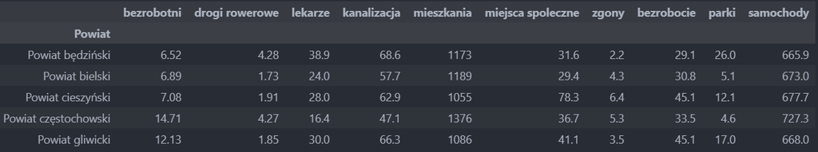

```python
tabela.head()
```

Odrazu sprawdzam czy nie ma jakichś wartości brakujących

```python
tabela.isnull().sum()
```

```
## bezrobotni           0
## drogi rowerowe       0
## lekarze              0
## kanalizacja          0
## mieszkania           0
## miejsca spoleczne    0
## zgony                0
## bezrobocie           0
## parki                0
## samochody            0
## dtype: int64
```

Dane są bez braków.

## Zmienne diagnostyczne

Wszystkie dane pochodzą z BDL i są z 2022 roku.

Wybrane przeze mnie zmienne diagnostyczne wyglądają następująco:

- ‘bezrobotni’ bezrobotni na 1 ofertę pracy. Wskaźnik jest liczony według wzoru: osoby zarejstrowane jako bezrobotne(suma stanów miesięcznych)/ suma ofert pracy w ciągu roku.
- ‘drogi rowerowe’ długość drogi rowerowej przypadającej na 10 tys. ludności
- ‘lekarze’ ilość lekarzy(ogółem) przypadająca na 10 tys. ludności
- ‘kanalizacja’ korzystający z instalacji w % ogółu ludności
- ‘mieszkania’ mieszkania oddane do użytkowania na 1000 zawartych małżeństw
- ‘miejsca spoleczne’ placówki stacjonarnej pomocy społecznej na 10 tys. ludności
- ‘zgony’ zgony niemowląt na 1000 żywych urodzeń
- ‘bezrobocie’ udział bezrobotnych pozsotających bez pracy dłużej niż rok w bezrobotnych ogółem
- ‘samochody’ samochody osobowe na 1000 ludności
- ‘parki’ powierzchnia parków,zieleńców i terenów zieleni osiedlowej na 1 mieszkańca w m2

## Statystyki opisowe

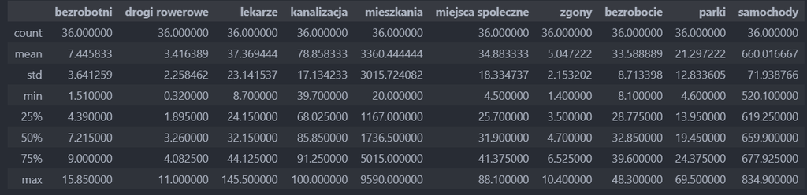

```python
print(tabela.describe())
```

## Wykrest gętości

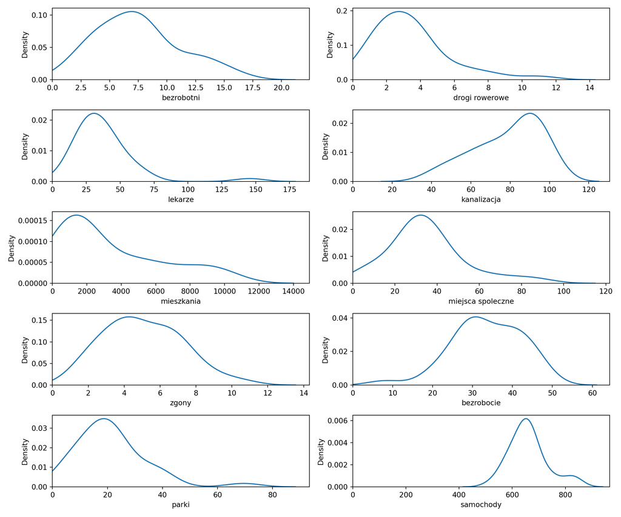

## Korelacje

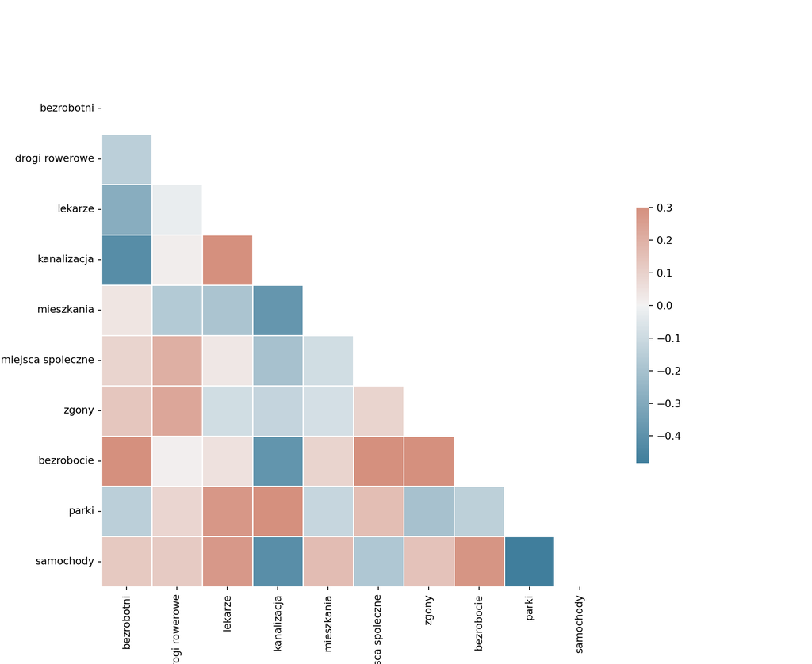

```python
corr=tabela.corr()

mask = np.triu(np.ones_like(corr, dtype=bool))


f, ax = plt.subplots(figsize=(11, 9))


cmap = sns.diverging_palette(230, 20, as_cmap=True)


sns.heatmap(corr, mask=mask, cmap=cmap, vmax=.3, center=0,
            square=True, linewidths=.5, cbar_kws={"shrink": .5})
```

Występuje kilka umiarkowanych zależności m.in.:

- ilością samochodów a parków
- ilością samochodów a dostępem do kanalizacji
- bezrobociem powyżej roku a dostępem do kanalizacji

# Porządkowanie liniowe

## Zamiana na stymulanty

W naszych danych występują następujące destymulanty: *bezrobotni,bezrobocie,zgony*. Do przeprowadzenia porządkowania liniowego potrzebuję samych stymulant, więc mnożę te zmienne przez -1.

```python
tabela[['zgony','bezrobocie','bezrobotni']]=tabela[['zgony','bezrobocie','bezrobotni']]* -1
```

## Metody bezworcowe

### Metoda standaryzowanych sum

Metoda standaryzowanych sum należy do technik bezwzorcowych porządkowania liniowego. Po uprzednim zmienieniu zmiennych diagnostycznych na stymulanty i standaryzacji sumuję oszacowania uzyskane w ramach obiektów według wzoru:
$$s_i = \frac{1}{m} \sum_{j=1}^{m} \alpha_i z_{ij}$$

Przeprowadzam standaryzację danych.

```python
from sklearn.preprocessing import MinMaxScaler,StandardScaler

normalizer=StandardScaler()
minmax=MinMaxScaler()


df=pd.DataFrame(normalizer.fit_transform(tabela.copy()),columns=tabela.columns,index=tabela.index)
```

Po przeprowadzeniu standaryzacji tak wyglądają przykładowe wiersze tabeli.

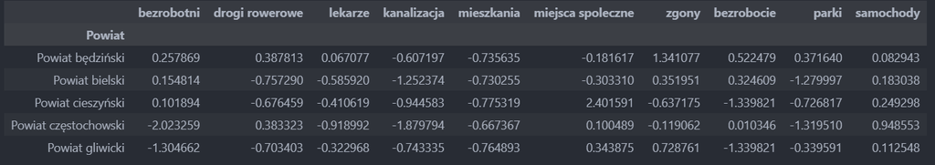

```python
df.head()
```

Następnie sumuje wartości każdej zmiennej i na koniec unitaryzuję wskaźnik syntetyczny ‘WSK’, by był na przedziale od 0 do 1. Poniżej znajdują się wyniki metody standaryzowanych sum:

```python
df['WSK']=df.sum(axis=1)/len(df.columns)
df['WSK']=minmax.fit_transform(df['WSK'].values.reshape(-1,1))
df['WSK'].nlargest(7)
```

```
## Powiat
## Powiat m. Katowice            1.000000
## Powiat m. Chorzów             0.928437
## Powiat m. Tychy               0.920181
## Powiat m. Ruda Śląska         0.843420
## Powiat m. Dąbrowa Górnicza    0.808018
## Powiat m. Częstochowa         0.723882
## Powiat m. Bielsko-Biała       0.693791
## Name: WSK, dtype: float64
```

Najwyższy syntetyczny wskaźnik ma miasto Katowice, następnie jest Chorzów i Tychy. Warto zauważyć że między 2 i 3 miejscem różnica jest minimalna.

### Metoda sum rang

W metodzie sum rang nadaję rangi poszególnym wierszom w każdej kolumnie (od najmniejszej do największej), a następnie sumuję rangi dla każdego wiersza. Na koniec przeprowadzam unitaryzację. Poniżej znajduje się tabelka z wynikami metody sum rang:

```python
df1=tabela.copy()
for column in df1.columns:
    nazwa=str(column)
    df1[nazwa]=df1[column].rank()

df1['WSK']=df1.sum(axis=1)
df1['WSK']=minmax.fit_transform(df1['WSK'].values.reshape(-1,1))

df1['WSK'].nlargest(7)
```

```
## Powiat
## Powiat m. Tychy               1.000000
## Powiat m. Częstochowa         0.897361
## Powiat m. Chorzów             0.891496
## Powiat m. Dąbrowa Górnicza    0.876833
## Powiat m. Ruda Śląska         0.873900
## Powiat m. Katowice            0.821114
## Powiat m. Bielsko-Biała       0.768328
## Name: WSK, dtype: float64
```

W przypadku sum rang widzimy zmiany w porównaniu do metody standaryzowanych sum. Na pierwszym miejscu są tym razem Tychy, potem Częstochowa i Chorzów. Przy użyciu tej metody Katowice znalazły się na miejscu 6.

## Metoda wzorcowa

### Metoda Hellwiga

W przypadku metody Hellwiga na początku przeprowadzam standaryzację. Następnie znajduję maksymalne wartości dla każdej zmiennej diagnostycznej i uzyskuję wzorzec.

W następnym kroku liczę odległości obiektów od wzorca ze wzoru:
$$d_i = \sqrt{\sum (x_{ij} - d_j^+)^2}$$

Wyznaczam odległość możliwie daleką i w ostatnim kroku wyznaczam WSK.

Poniżej znajduje się tabela z wynikami metody Hellwiga:

```python
df2=pd.DataFrame(normalizer.fit_transform(tabela.copy()),index=tabela.index,columns=tabela.columns)
wzorzec=np.array(df2.max(axis=0))
def oblicz_di(wiersz, wzorzec):
    return np.sqrt(np.sum((wiersz - wzorzec) ** 2))

df2['odleglosc'] = df2.drop(columns='odleglosc', errors='ignore').apply(lambda row: oblicz_di(row.values, wzorzec), axis=1)
odlegosc_daleka=np.mean(df2['odleglosc'])+2*np.std(df2['odleglosc'])
df2['WSK']=1-(df2['odleglosc']/odlegosc_daleka)
df2['WSK'].nlargest(7)
```

```
## Powiat
## Powiat m. Katowice            0.336313
## Powiat m. Tychy               0.327538
## Powiat m. Chorzów             0.321857
## Powiat m. Częstochowa         0.290204
## Powiat m. Dąbrowa Górnicza    0.271375
## Powiat m. Bielsko-Biała       0.269586
## Powiat m. Zabrze              0.263542
## Name: WSK, dtype: float64
```

Najlepszym miastem tym razem okazują się Katowice, następnie Tychy i Chorzów.

# Podsumowanie porządkowania liniowego

## Wykresy radarowe

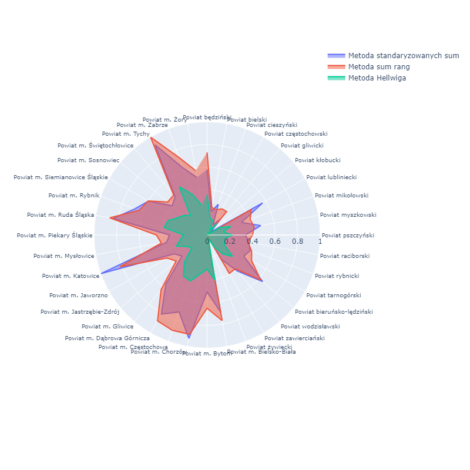

Wyniki wszystkich trzech metod są ze sobą całkiem zgodne i można by rzec że Tychy bądź Katowice są najlepszym miejscem do mieszkania. Jednocześnie widzimy znaczące zróżnicowanie poziomu życia między powiatami miejskimi a grodzkimi.

Na powyższym wykresie prawie cała prawa strona zawiera głównie powiaty grodzkie i jest znacznie mniejsza niż lewa z powiatami miejskimi, co ilustruje nam te znaczące zróżnicowanie w poziomie życia.

## Korelacje

Zbadam teraz korelacje jakie wystąpiły między metodami, aby sprawdzić czy wyniki w miarę się pokrywają.

```python
metody=pd.DataFrame({'standSum':df['WSK'],'sumRang':df1['WSK'],'hellwig':df2['WSK']})
corrmetody=metody.corr()
```

Pearson:

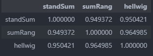

```python
metody=pd.DataFrame({'standSum':df['WSK'],'sumRang':df1['WSK'],'hellwig':df2['WSK']})
corrmetody=metody.corr(method='kendall')
```

Tau-Kendall:

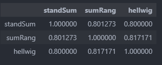

W przypadu korelacji liniowej Pearsona występują bardzo wysokie korelacje między wykorzystanymi przeze mnie metodami. Gdy użyjemy Tau-Kendalla korelacje te są niższe, ale nadal mówimy tu o wysokiej zgodności ze sobą. Można powiedzieć, że metoda Hellwiga trochę bardzej podobnie uporządkowała wyniki jak metoda sum rang niż metoda standaryzowanych sum,

# Analiza skupień

Zanim zaczniemy przeprowadzać analizę skupień usunę wartości odstające, gdyż mogą one znacznie wpływać na wyniki grupowań. Aby to zrobić, skorzystam z własności reguły 3 sigm i sprawdzę gdzie po standaryzacji danych jakieś wartości są większe od 3 lub mniejsze od -3

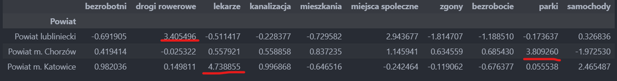

```python
df3=pd.DataFrame(normalizer.fit_transform(tabela.copy()),columns=tabela.columns,index=tabela.index)

print(df3[((df3 > 3) | (df3<-3)).any(axis=1)])
```

Mamy 3 powiaty, które po standaryzacji w jednej ze zmiennych diagnostycznych uznajemy za wartości odstające. Postanowiłem, że nie będę usuwał całych wierszy tylko w zmiennych diagnostycznych, które są wartościami odstającymi ustawię wartość 3 lub -3.

```python
df3.loc['Powiat lubliniecki','drogi rowerowe']=3
df3.loc['Powiat m. Chorz\u00f3w','parki']=3
df3.loc['Powiat m. Katowice','lekarze']=3
```

## K-means

Metoda k-średnich jest metodą grupowania podziałowego i opiera się na przenoszeniu obiektów ze skupienia do skupienia tak długo aż zostaną zoptymalizowanie zmienności wewnątrz skupień oraz pomiędzy skupieniami. Przyjmując, że odległość między obiektami jest definiowana metryką *d*, uzyskuje się warunek:
$$\min
\left\{ \sum_{n=1}^{N} \frac{1}{\# G_n} \sum_{P_i, P_j \in G_n} d(P_i,
P_j) \right\}$$

Na początek sprawdźmy ile skupień powinniśmy ustawić. W tym celu ma nam pomóc przygotowany przeze mnie wykres. Parametr *inertia* mierzy jak dobrze nasze dane zostały podzielone przez k-średnich.

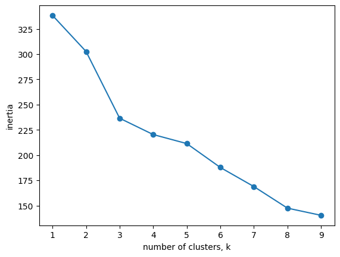

```python
from sklearn.cluster import KMeans
from sklearn.decomposition import PCA

ks = range(1, 10)
inertias = []

for k in ks:

    model=KMeans(n_clusters=k)
    inertias.append(model.fit(df3).inertia_)
```

Generalnie powinniśmy przyjąć takie k, aby różnica między następnym k zaczęła robić się minimalna. Na powyższym wykresie taki moment zaczyna się po k=3 do k=5. Niestety w naszym przypadku wykres ten nie jest tak pomocny, więc sprawdzimy kilka opcji.

### Dwa klastry

```python
np.random.seed(42)
pca=PCA(2)
df31=pca.fit_transform(df3.copy())
knn=KMeans(n_clusters=2)
label=knn.fit_predict(df31)

u_labels = np.unique(label)
```

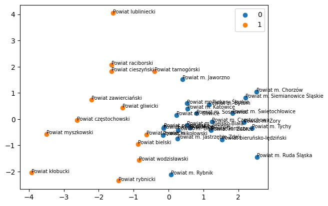

Aby pokazać wyniki na powyższym wykresie użyłem techniki PCA, która zmniejszyła wymiary moich danych tak, by można je było przedstawić na wykresie w dwóch wymiarach.

[figure not shown]

W przypadku gdy mamy dwa klastry podział został przeprowadzony głównie na powiaty miejskie i grodzkie. Powiaty grodzkie zostały przydzielone do grupy pierwszej (pomarańczowej), a powiaty miejskie do grupy zerowej (niebieskie). W zasadzie możemy powiedzieć, że do grupy pierwszej nie zostało przydzielone żadne miasto, ale już w grupie zerowej znajdziemy kilka wyjątków takich jak:

```python
clusters=pd.DataFrame({'cluster':label},index=tabela.index)
#clusters[clusters['cluster'] == 0].head()
```

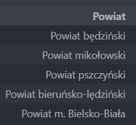

Widzimy 4 powiaty grodzkie, które zostały zaliczone do grupy tych ‘miejskich’. W przypadku powiatu bieruńsko-lędzińskiego przyczyną może być fakt, że na terenie znajduje się kopalnia węgla kamiennego, co może prowadzić do większych dochodów powiatu. W powiecie będzińskim znajduje się dość spore miasto Będziń, które nie ma własnego powiatu, więc jest włączone do powiatu będzińskiego. Podobna sytuacja występuje w powiecie mikołowskim, gdzie włączone jest spore miasto Mikołów. Natomiast powiatu pszczyńskiemu możemy przyjrzeć się bliżej:

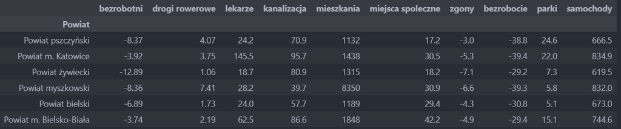

```python
tabela.loc[['Powiat pszczyński', 'Powiat m. Katowice','Powiat żywiecki','Powiat myszkowski','Powiat bielski','Powiat m. Bielsko-Biała']]
```

Dla porównania pokazuję również kilka miast i powiatów. Powodem przez który powiat pszczyński znalazł się w grupie powiatów miejskich wydaje się być fakt sporej liczby powierzchni parków na 1 mieszkańca oraz niskim wskaźnikiem zgonów niemowląt. Jest też bardzo możliwe, że powiat ten jest na granicy tych dwóch klastrów i akurat trafił do tych miejskich.

### Trzy klastry

```python
pca=PCA(2)
df32=pca.fit_transform(df3.copy())
knn=KMeans(n_clusters=3)
label=knn.fit_predict(df32)

u_labels = np.unique(label)
```

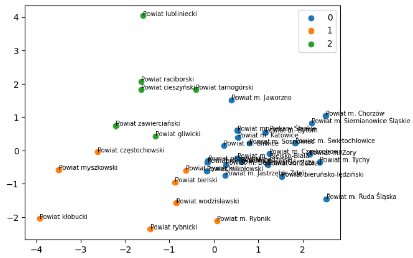

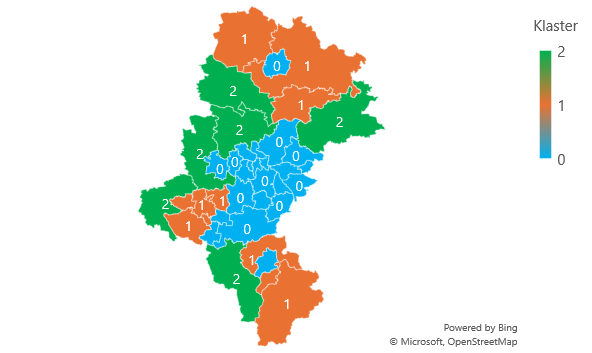

Tak wygląda podział powiatów na 3 klastry. Jako że w przypadku 3 klastrów podział jest prosty - duże miasta zostały podzielone na jedną grupę, a powiaty grodzkie na dwie mniejsze grupki pozwolę sobie przejść do analizy czterech klastrów, która wydaje się być bardziej trafna.

### Cztery klastry

```python
np.random.seed(42)
pca=PCA(2)
df3=pca.fit_transform(df3)
knn=KMeans(n_clusters=4)
label=knn.fit_predict(df3)

u_labels = np.unique(label)
```

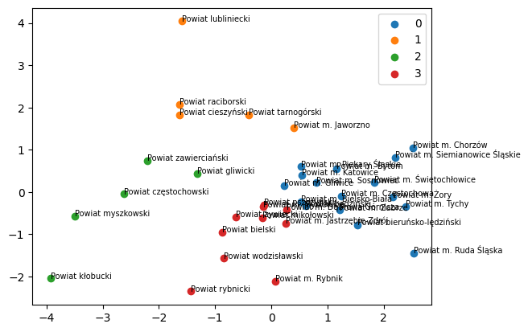

Gdy ustawimy podział na 4 klastry otrzymamy takie wyniki. Wykres nie jest do końca czytelny przedstawię teraz jakie powiaty należą do każdej z grup i postaram się wyjaśnić dlaczego tak może być. Przedstawiam powiaty na mapie:

[figure not shown]

```python
clusters1=pd.DataFrame({'cluster':label},index=tabela.index)
#clusters1[clusters1['cluster'] == 0]
```

#### Klaster 0

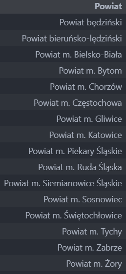

W klastrze 0 znalazły się głównie miasta konurbacji górnośląskiej np. Katowice, Gliwice, Zabrze, Bytom itd. Wyjątkami są Częstochowa, Bielsko-Biała oraz Żory. Tak naprawdę ta grupa przedstawia największe i najważniejsze miasta na Śląsku.

```python
clusters1=pd.DataFrame({'cluster':label},index=tabela.index)
#clusters1[clusters1['cluster'] == 1]
```

#### Klaster 1

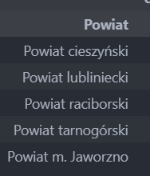

#### Klaster 2

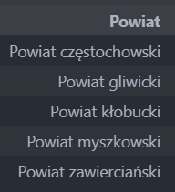

#### Klater 3

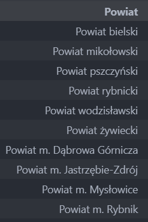

## Podsumowanie k-średnich

Oczywisty podział na dwa klastry pokazuje nam, że występują różnice między powiatami grodzkimi i miejskimi.

W przypadku podziału na cztery klastry możemy zauważyć jak bardzo zróżnicowany pod względem rozwoju jest Śląsk. Jest to zapewne spowodowane historią, gdzyż podział na te klastry w jakimś stopniu zgadza się z historycznym podziałem Śląska, który znajdował się w 3 zaborach - na północnym zachodzie oraz zachodzie, czyli w terenach konurbacji śląskiej, był w zaborze pruskim (klastry 0 i 1 oraz część klastra 3); na południowym wschodzie, czyli terenach blisko Bielska-Białej (klaster 3), tereny były pod zaborem austriackim; a na samej północy w okolicach Częstochowy w zaborze rosyjskim (klaster 2).

Bardziej uwidocznione jest to na powiatach grodzkich, gdyż miejskie szybciej się rozwineły i z biegiem czasu bardzo zbliżyły się do siebie. Większość dużych miast trafia do jednego worka pomimo wcześniejszych podziałów.

Poniżej przedstawiam mapkę przedstawiającą jak podzielony był Śląsk podczas zaborów w latach 1795-1918 (podział jest przedstawiony białą linią). Dodatkowo jeszcze na mapce widzimy podział kolorami na dawne województwo Śląskie i Małopolskie. Co ciekawe aktualne tereny województwa Śląskiego składają się w prawie połowie z terenów dawnego województwa Małopolskiego.

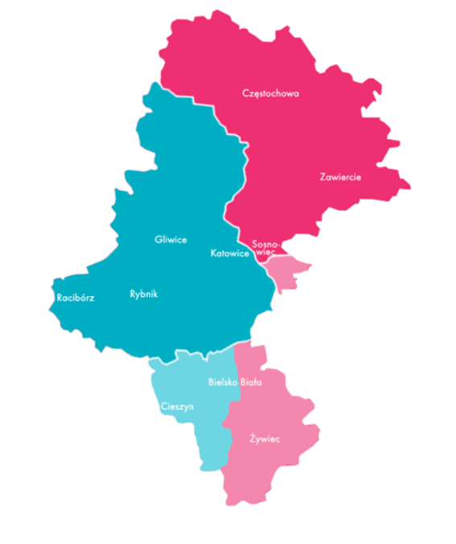

**źródło: wslaskie.pl**

## Grupowanie hierarchiczne

W odróżnieniu do grupowania porządkowego, algorytm ten sam ustala liczbę klastrów. Wykorzystuje się tutaj funkcję odległości. Każdy element zbioru jest łączony w coraz większe grupy aż do uzyskania jednego skupienia, który zawiera wszystkie obiekty.W moich obliczeniach wykorzystam metodę Warda, która bazuje na ANOVA. Na każdym etapie minimaluzuje się wzrost łącznej sumy kwadratów odchyleń wszystkich cech dla każdego obiektu w obrębie grupy od średnich w skupieniu.

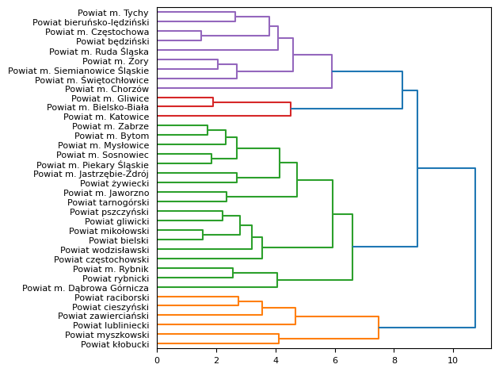

```python
from scipy.cluster.hierarchy import dendrogram, linkage
df4=pd.DataFrame(normalizer.fit_transform(tabela.copy()),columns=tabela.columns,index=tabela.index)
linkage_data=linkage(df4,method='ward',metric='euclidean')
```

Algorytm w pózniejszym etapie połączył klaster czerwony z fioletowym, przez co powstał nam klaster z w zasadzie najważniejszymi miastami Śląska. W kolejnym kroku połączył się on z klastrem zielonym.

W przypadku grupowania hierarchicznego, algorytm sam ustalił 4 główne klastry:

### Klaster fioletowy

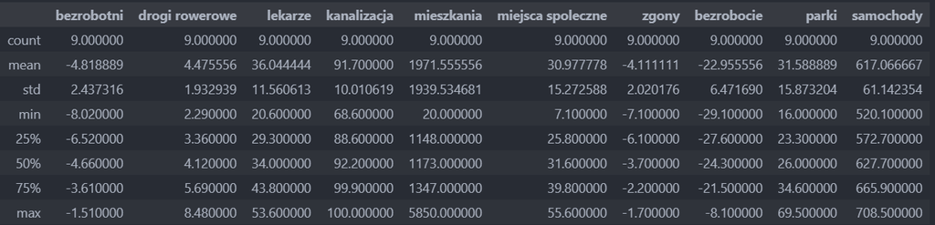

Statystyki jednoznacznie wskazują na spore miasta, na co wskazuje chociażby fakt że procent dostępu do kanalizacji jest bardzo wysoki. W tym klastrze również występuje stosunkowo niskie bezrobocie i spora powierzchnia parków, co najbardziej wyróżnia go od drugiego klastra z miastami.

### Klaster czerwony

Znalazły się tam 3 duże miasta - Katowice, Gliwice i Bielsko-Biała.

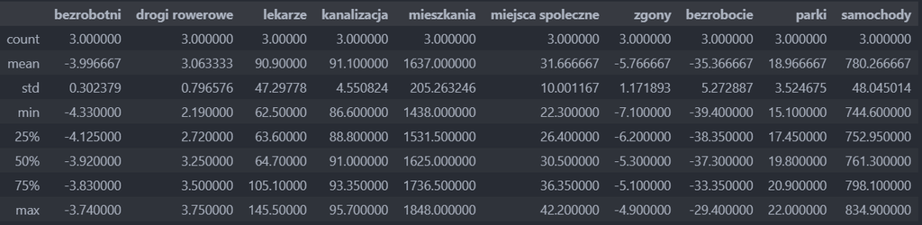

**Klaster lekarzy**. Zdecydowanie cechą która ten klaster może opisać jest wysoka dostępność lekarzy na 10 tys. ludności.

### Klaster zielony

Znajduje się tam większość powiatów grodzkich oraz kilka większych miast z Konurbacji górnośląskiej takich jak Zabrze, Bytom.

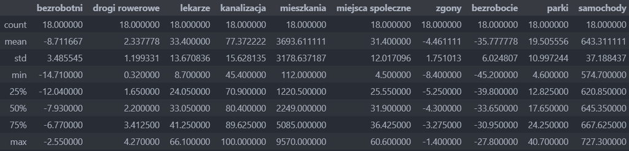

Można go uznać za taki pomieszany klaster - z jednej strony mamy dość dużo oddanych mieszkań na 1000 małżeństw, co charakteryzuje powiaty grodzkie, a z drugiej jeszcze dość wysoki wskaźnik dostępu kanalizacji co jest bardziej podobne do miast.

### Klaster pomarańczowy

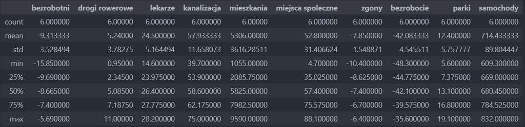

Wysoka ilość osób bezrobotnych na 1 ofertę pracy oraz duża liczba oddanych mieszkań na 1000 małżeństw najbardziej wyróżnia ten klaster.

# Podsumowanie

Analiza skupień natomiast podzieliła na grupy wszystkie powiaty. Co ciekawe, podział uzyskany metodą k-średnich z 4 klastrami pokrywa się w jakimś stopniu z zaborami Polski, gdyż Śląsk w tamtym czasie znajdował się we wszystkich trzech zaborach. Po ustawieniu 2 klastrów wyszedł również oczywisty podział na powiaty miejskie i grodzkie z kilkoma wyjątkami. To również pokazuje nam, że zróżnicowanie poziomu życia występuje w całym województwie. Pojawiały się nawet pomysły, żeby województwo zmieniło nazwę na Śląsko-Małopolskie, właśnie ze względu na duże zróżnicowanie kulturowe różnych regionów tego województwa.